# Studying Association of Hypertension with Potential Risk Factors

# 1 Setup and Data Ingest

## 1.1 Initial Setup and Package Loads

```r
library(nhanesA)
library(knitr)
library(rmdformats)
library(car)
library(equatiomatic)
library(gt)
library(gtExtras)
library(ggrepel)
library(ggdist)
library(janitor)
library(naniar)
library(broom)
library(patchwork)
library(kableExtra)
library(readxl)
library(Epi)
library(Hmisc)
library(tidyverse)

## Load Love-boost
source("Love-boost.R")

## Global options
knitr::opts_chunk$set(comment = NA)

theme_set(theme_bw())
```

## 1.2 Loading the raw data

```r
demo_raw <- nhanes('P_DEMO') %>% tibble()%>% clean_names()
sbp_raw <- nhanes("P_BPXO")%>% tibble()%>% clean_names()
salt_raw <- nhanes("P_DR1TOT")%>% tibble()%>% clean_names()
hypertension_raw <- nhanes("P_BPQ")%>% tibble()%>% clean_names()
tobacco_raw <- nhanes("P_SMQRTU")%>% tibble()%>% clean_names()
weight_raw <- nhanes("P_WHQ")%>% tibble()%>% clean_names()
activity_raw <- nhanes("P_PAQ")%>% tibble()%>% clean_names()
```

## 1.3 Contents of the Raw Tibbles

We have seven tibbles now.

- `demo_raw` contains data on all 29 variables for 15560 subjects.

```r
dim(demo_raw)
```

```
[1] 15560    29
```

- `sbp_raw` contains data on 12 of the variables for 11656 subjects.

```r
dim(sbp_raw)
```

```
[1] 11656    12
```

- `salt_raw` contains data on 168 of the variables for 14300 subjects.

```r
dim(salt_raw)
```

```
[1] 14300   168
```

- `hypertension_raw` contains data on 11 of the variables for 10195 subjects.

```r
dim(hypertension_raw)
```

```
[1] 10195    11
```

- `tobacco_raw` contains data on 25 of the variables for 10409 subjects.

```r
dim(tobacco_raw)
```

```
[1] 10409    25
```

- `weight_raw` contains data on 35 of the variables for 10195 subjects.

```r
dim(weight_raw)
```

```
[1] 10195    35
```

- `activity_raw` contains data on 17 of the variables for 9693 subjects.

```r
dim(activity_raw)
```

```
[1] 9693   17
```

## 1.4 Two Merging Steps

1. Selecting all the variables that I’ll be using in my study.

```r
demo <- demo_raw %>% select(seqn, ridstatr, ridageyr, riagendr) %>%
  filter(ridstatr==2) %>%
  filter(ridageyr %in% (18:70))

sbp <- sbp_raw |> select(seqn, bpxosy1)


salt <- salt_raw |> select(seqn, drqsprep)

hypertension <- hypertension_raw |> select(seqn, bpq020)

tobacco <- tobacco_raw |> select(seqn, smq681)

weight <- weight_raw |> select(seqn, whq030)

activity <- activity_raw |> select(seqn, paq605)
```

2. Joining these variables to form a data set

```r
temp_1 <- left_join(demo, sbp, by="seqn")
temp_2 <- left_join(temp_1, salt, by="seqn")
temp_3 <- left_join(temp_2, hypertension, by="seqn")
temp_4 <- left_join(temp_3, tobacco, by="seqn")
temp_5 <- left_join(temp_4, weight, by="seqn")
temp_6 <- left_join(temp_5, activity, by="seqn")
dim(temp_6)
```

```
[1] 7611   10
```

```r
clean_names(temp_6)
```

```
# A tibble: 7,611 × 10
     seqn ridstatr ridageyr riagendr bpxosy1 drqsp…¹ bpq020 smq681 whq030 paq605
    <dbl>    <dbl>    <dbl>    <dbl>   <dbl>   <dbl>  <dbl>  <dbl>  <dbl>  <dbl>
 1 109266        2       29        2      99       4      2      2      1      2
 2 109271        2       49        1     102       1      2      1      3      2
 3 109273        2       36        1     116       2      2      1      2      1
 4 109274        2       68        1     138       2      1      2      1      1
 5 109284        2       44        2      NA       4      2      2      1      2
 6 109286        2       33        2      NA       4      2     NA      1      2
 7 109290        2       68        2     126       1      1      2      3      2
 8 109291        2       42        2     107       2      1      2      3      2
 9 109292        2       58        1     143      NA      1      1      1      2
10 109293        2       44        1     126       9      2      2      1      2
# … with 7,601 more rows, and abbreviated variable name ¹drqsprep
```

## 1.5 Checking the Merge

Checking to ensure that the number of distinct (unique) subject identification codes (shown below) matches the number of rows. Those two values should be identical.

```r
identical(n_distinct(temp_6$seqn),
         temp_6 |> nrow())
```

```
[1] TRUE
```

All right. Our merge was successful.

# 2 Checking for missingness

```r
miss_var_summary(temp_6)
```

```
# A tibble: 10 × 3
   variable n_miss pct_miss
   <chr>     <int>    <dbl>
 1 bpxosy1     740     9.72
 2 drqsprep    629     8.26
 3 smq681      471     6.19
 4 seqn          0     0
 5 ridstatr      0     0
 6 ridageyr      0     0
 7 riagendr      0     0
 8 bpq020        0     0
 9 whq030        0     0
10 paq605        0     0
```

I have assumed that my data is missing completely at random (MCAR). For further analysis, I’ll be using only complete cases.

## 2.1 Dropping all the Null values

```r
temp_6[temp_6 ==9 ] <- NA
temp_6[temp_6==7] <- NA
temp_6 |> drop_na()
```

```
# A tibble: 6,299 × 10
     seqn ridstatr ridageyr riagendr bpxosy1 drqsp…¹ bpq020 smq681 whq030 paq605
    <dbl>    <dbl>    <dbl>    <dbl>   <dbl>   <dbl>  <dbl>  <dbl>  <dbl>  <dbl>
 1 109266        2       29        2      99       4      2      2      1      2
 2 109271        2       49        1     102       1      2      1      3      2
 3 109273        2       36        1     116       2      2      1      2      1
 4 109274        2       68        1     138       2      1      2      1      1
 5 109290        2       68        2     126       1      1      2      3      2
 6 109291        2       42        2     107       2      1      2      3      2
 7 109295        2       54        2     158       4      2      2      3      2
 8 109297        2       30        2     105       3      2      1      3      1
 9 109298        2       68        1      94       2      1      2      1      1
10 109300        2       54        2     155       4      2      2      3      2
# … with 6,289 more rows, and abbreviated variable name ¹drqsprep
```

```r
study1_m <- temp_6 |> select(seqn, ridstatr, ridageyr, riagendr, bpxosy1, drqsprep, bpq020, smq681, whq030, paq605) |> drop_na()
```

# 3 Cleaning the Data

## 3.1 Study Variables

The 7 study variables that we will actually use in this demonstration are listed below.

### 3.1.1 Sequence Variable

Each subject has a unique sequence id.

1. `seqn` is the sequence id unique to each subject.

### 3.1.2 Quantitative Variables

2. `bpxosy1`: Systolic - 1st oscillometric reading in mmHg

### 3.1.3 Binary Variables

3. `paq605`: Does your work involve vigorous-intensity activity? (Yes, No)
4. `bpq020`: Ever told you had high blood pressure? (Yes, No)
5. `smq681` : Ever smoked tobacco in the last five days? (Yes, No)

### 3.1.4 Multi-Categorical Variables

Note that we’ve already checked our subject identification codes to ensure that we have no missing values there and that we have a unique identifier for each row in the data back when we did the merge.

## 3.2 Checking our Quantitative Variables

I have a quantitative variable. I want to check the range (minimum and maximum) plus missingness, to ensure that we have no impossible or missing values.

```r
study1_m |> select(bpxosy1)|>
  mosaic::inspect()
```

```
quantitative variables:
     name   class min  Q1 median  Q3 max     mean       sd    n missing
1 bpxosy1 numeric  66 109    119 131 219 121.8893 18.17669 6299       0
```

- For this variable, all values are in the range, as they must be.

## 3.3 Checking our Binary Variables

We have four binary variables.

```r
study1_m |> select(riagendr, smq681, bpq020, paq605) |> summary()
```

```
    riagendr         smq681          bpq020          paq605
 Min.   :1.000   Min.   :1.000   Min.   :1.000   Min.   :1.000
 1st Qu.:1.000   1st Qu.:2.000   1st Qu.:1.000   1st Qu.:1.000
 Median :2.000   Median :2.000   Median :2.000   Median :2.000
 Mean   :1.511   Mean   :1.754   Mean   :1.676   Mean   :1.719
 3rd Qu.:2.000   3rd Qu.:2.000   3rd Qu.:2.000   3rd Qu.:2.000
 Max.   :2.000   Max.   :2.000   Max.   :2.000   Max.   :2.000
```

I’d like those to be factors in R, rather than characters.

```r
study1_m <- study1_m %>% mutate(riagendr_f = fct_recode(factor(riagendr),
"Male" = "1", "Female" = "2"),
riagendr_f= fct_relevel(riagendr_f, "Male"))
study1_m %>% tabyl(riagendr_f)
```

```
 riagendr_f    n   percent
       Male 3080 0.4889665
     Female 3219 0.5110335
```

```r
study1_m <- study1_m %>% mutate(smq681_f = fct_recode(factor(smq681),
"Smoker" = "1", "Non-smoker" = "2"),
smq681_f=fct_relevel(smq681_f, "Smoker"))
study1_m %>% tabyl(smq681_f)
```

```
   smq681_f    n  percent
     Smoker 1549 0.245912
 Non-smoker 4750 0.754088
```

```r
study1_m <- study1_m %>% mutate(bpq020_f = fct_recode(factor(bpq020),
"Hypertension" = "1", "No Hypertension" = "2"),
bpq020_f= fct_relevel(bpq020_f, "Hypertension"))
study1_m %>% tabyl(bpq020_f)
```

```
        bpq020_f    n   percent
    Hypertension 2043 0.3243372
 No Hypertension 4256 0.6756628
```

```r
study1_m <- study1_m %>% mutate(paq605_f = fct_recode(factor(paq605),
"Yes" = "1", "No" = "2"),
paq605_f= fct_relevel(paq605_f, "Yes"))
study1_m %>% tabyl(paq605_f)
```

```
 paq605_f    n   percent
      Yes 1771 0.2811557
       No 4528 0.7188443
```

```r
study1_m |> select(riagendr_f, smq681_f, bpq020_f, paq605_f) |> summary()
```

```
  riagendr_f         smq681_f               bpq020_f    paq605_f
 Male  :3080   Smoker    :1549   Hypertension   :2043   Yes:1771
 Female:3219   Non-smoker:4750   No Hypertension:4256   No :4528
```

OK. No missingness, and no values out of the range of our expectations. Good.

## 3.4 Checking our Multi-Category Variables

For each of our multi-categorical variables, I’ll run a quick `tabyl` to see if we have any surprising results or missing values. Then I’ll revise each of them (as needed) to have more suitable (mostly, shorter) level names. In addition to checking for missingness and inappropriate values, we want to collapse some categories, or adjust names or labeling to mirror what we need in our analyses.

### 3.4.1 The `whq030` variable

```r
study1_m <- study1_m |> mutate(whq030_f= fct_recode(factor(whq030),
"Overweight" = "3", "Underweight" = "2", "Ideal_weight" = "1"),
whq030_f = fct_relevel(whq030_f, "Ideal weight"))
study1_m |> tabyl(whq030_f)
```

```
     whq030_f    n    percent
 Ideal_weight 3366 0.53437054
  Underweight  339 0.05381807
   Overweight 2594 0.41181140
```

```r
study1_m |> count(whq030, whq030_f)
```

```
# A tibble: 3 × 3
  whq030 whq030_f         n
   <dbl> <fct>        <int>
1      1 Ideal_weight  3366
2      2 Underweight    339
3      3 Overweight    2594
```

### 3.4.2 The `drqsprerp` variable

```r
study1_m <- study1_m |> mutate(drqsprep_f = fct_recode(factor(drqsprep),
"Never"= "1", "Rarely" = "2", "Occasionally" = "3", "Very Often" = "4"),
drqsprep_f= fct_relevel(drqsprep_f, "Never"))
study1_m |> tabyl(drqsprep_f)
```

```
   drqsprep_f    n    percent
        Never  526 0.08350532
       Rarely 1067 0.16939197
 Occasionally 1990 0.31592316
   Very Often 2716 0.43117955
```

```r
study1_m |> count(drqsprep, drqsprep_f)
```

```
# A tibble: 4 × 3
  drqsprep drqsprep_f       n
     <dbl> <fct>        <int>
1        1 Never          526
2        2 Rarely        1067
3        3 Occasionally  1990
4        4 Very Often    2716
```

- That looks like we’ve correctly renamed the values.
- We have no missing value here.

## 3.5 Creating the Analytic Tibble

So my analytic tibble, which I’ll call `study1` should contains only the ten variables that appear in our code book.

```r
study1 <- study1_m |> select(seqn, ridstatr, ridageyr, riagendr_f, bpxosy1, drqsprep_f, bpq020_f, smq681_f, whq030_f, paq605_f) |> glimpse()
```

```
Rows: 6,299
Columns: 10
$ seqn       <dbl> 109266, 109271, 109273, 109274, 109290, 109291, 109295, 109…
$ ridstatr   <dbl> 2, 2, 2, 2, 2, 2, 2, 2, 2, 2, 2, 2, 2, 2, 2, 2, 2, 2, 2, 2,…
$ ridageyr   <dbl> 29, 49, 36, 68, 68, 42, 54, 30, 68, 54, 18, 55, 47, 48, 63,…
$ riagendr_f <fct> Female, Male, Male, Male, Female, Female, Female, Female, M…
$ bpxosy1    <dbl> 99, 102, 116, 138, 126, 107, 158, 105, 94, 155, 103, 116, 1…
$ drqsprep_f <fct> Very Often, Never, Rarely, Rarely, Never, Rarely, Very Ofte…
$ bpq020_f   <fct> No Hypertension, No Hypertension, No Hypertension, Hyperten…
$ smq681_f   <fct> Non-smoker, Smoker, Smoker, Non-smoker, Non-smoker, Non-smo…
$ whq030_f   <fct> Ideal_weight, Overweight, Underweight, Ideal_weight, Overwe…
$ paq605_f   <fct> No, No, Yes, Yes, No, No, No, Yes, Yes, No, No, No, No, No,…
```

## 3.6 List of Missing Values

We can count the number of missing observations in each variable, with …

```r
miss_var_summary(study1)
```

```
# A tibble: 10 × 3
   variable   n_miss pct_miss
   <chr>       <int>    <dbl>
 1 seqn            0        0
 2 ridstatr        0        0
 3 ridageyr        0        0
 4 riagendr_f      0        0
 5 bpxosy1         0        0
 6 drqsprep_f      0        0
 7 bpq020_f        0        0
 8 smq681_f        0        0
 9 whq030_f        0        0
10 paq605_f        0        0
```

We can see the subjects do not have missing values.

## 3.7 Analytic Tibble

Now, I’ll prove that `study1` is a tibble by printing it.

```r
study1
```

```
# A tibble: 6,299 × 10
     seqn ridstatr ridageyr riagendr_f bpxosy1 drqspre…¹ bpq02…² smq68…³ whq03…⁴
    <dbl>    <dbl>    <dbl> <fct>        <dbl> <fct>     <fct>   <fct>   <fct>
 1 109266        2       29 Female          99 Very Oft… No Hyp… Non-sm… Ideal_…
 2 109271        2       49 Male           102 Never     No Hyp… Smoker  Overwe…
 3 109273        2       36 Male           116 Rarely    No Hyp… Smoker  Underw…
 4 109274        2       68 Male           138 Rarely    Hypert… Non-sm… Ideal_…
 5 109290        2       68 Female         126 Never     Hypert… Non-sm… Overwe…
 6 109291        2       42 Female         107 Rarely    Hypert… Non-sm… Overwe…
 7 109295        2       54 Female         158 Very Oft… No Hyp… Non-sm… Overwe…
 8 109297        2       30 Female         105 Occasion… No Hyp… Smoker  Overwe…
 9 109298        2       68 Male            94 Rarely    Hypert… Non-sm… Ideal_…
10 109300        2       54 Female         155 Very Oft… No Hyp… Non-sm… Overwe…
# … with 6,289 more rows, 1 more variable: paq605_f <fct>, and abbreviated
#   variable names ¹drqsprep_f, ²bpq020_f, ³smq681_f, ⁴whq030_f
```

## 3.8 Data Summary

Here’s a summary of the `study1` tibble.

```r
describe(study1)
```

```
study1

 10  Variables      6299  Observations
--------------------------------------------------------------------------------
seqn
       n  missing distinct     Info     Mean      Gmd      .05      .10
    6299        0     6299        1   117142     5210   110125   110885
     .25      .50      .75      .90      .95
  113214   117129   121093   123346   124108

lowest : 109266 109271 109273 109274 109290, highest: 124814 124815 124817 124818 124821
--------------------------------------------------------------------------------
ridstatr
       n  missing distinct     Info     Mean      Gmd
    6299        0        1        0        2        0

Value         2
Frequency  6299
Proportion    1
--------------------------------------------------------------------------------
ridageyr
       n  missing distinct     Info     Mean      Gmd      .05      .10
    6299        0       53        1    44.69    18.02       19       22
     .25      .50      .75      .90      .95
      31       46       59       65       68

lowest : 18 19 20 21 22, highest: 66 67 68 69 70
--------------------------------------------------------------------------------
riagendr_f
       n  missing distinct
    6299        0        2

Value        Male Female
Frequency    3080   3219
Proportion  0.489  0.511
--------------------------------------------------------------------------------
bpxosy1
       n  missing distinct     Info     Mean      Gmd      .05      .10
    6299        0      130        1    121.9    19.84       97      101
     .25      .50      .75      .90      .95
```

[output cut: 29 more lines]

```
       n  missing distinct
    6299        0        3

Value      Ideal_weight  Underweight   Overweight
Frequency          3366          339         2594
Proportion        0.534        0.054        0.412
--------------------------------------------------------------------------------
paq605_f
       n  missing distinct
    6299        0        2

Value        Yes    No
Frequency   1771  4528
Proportion 0.281 0.719
--------------------------------------------------------------------------------
```

# 4 Codebook and Data Description

## 4.1 Codebook

The variables in our data set `study1` for this demonstration are as follows. The Type column indicates the number of levels in each categorical (factor) variable. I’m using Quant to indicate quantitative variables, and Cat-x indicates a categorical variable (factor) with x levels.

[output not shown]

# 5 Analysis B: Compare 2 Population Means using Independent Samples

## 5.1 The Question

I’ll compare `bpxosy1` by `paq605_f` in this analysis using independent samples. We’re comparing the mean `bpxosy1` of the population represented by respondents who do vigorous physical activity to the mean `bxosy1` of the population represented by the respondents who aren’t involved in any vigorous physical activity. There is nothing to suggest that the two samples are paired or matched in any way. Plus, as we’ll see, there are different numbers of physically active and physically inactive subjects, so there’s no way their `bpxosy1` values could be paired. As a result, I’m going to be interested in looking at the two samples separately to help us understand issues related to hypothesis testing assumptions.

Our research question is:

Did subjects who are physically active have meaningfully different systolic blood pressure values than subjects who aren’t physically active?

## 5.2 Describing the Data

I’ll start by looking at the range of the `bpxosy1` data within each activity group

```r
analysis_b <- study1 |> select(seqn, ridstatr, ridageyr, riagendr_f, bpxosy1, drqsprep_f, bpq020_f, smq681_f, whq030_f, paq605_f)

mosaic::favstats(bpxosy1 ~ paq605_f, data = analysis_b) |>
    kable(dig=2) |> kable_styling(font_size = 18)
```

| paq605_f | min | Q1 | median | Q3 | max | mean | sd | n | missing |
| --- | --- | --- | --- | --- | --- | --- | --- | --- | --- |
| Yes | 66 | 111 | 120 | 131 | 219 | 122.32 | 16.76 | 1771 | 0 |
| No | 76 | 108 | 119 | 132 | 213 | 121.72 | 18.70 | 4528 | 0 |

We have 1771 subjects who are involved in intense physical activity, while 4528 subjects are not physically active. However, the average systolic blood pressure in both these categories is almost similar, while the median is different.

### 5.2.1 Graphical Summaries

Let’s build a comparison boxplot (with notches and violins) to start.

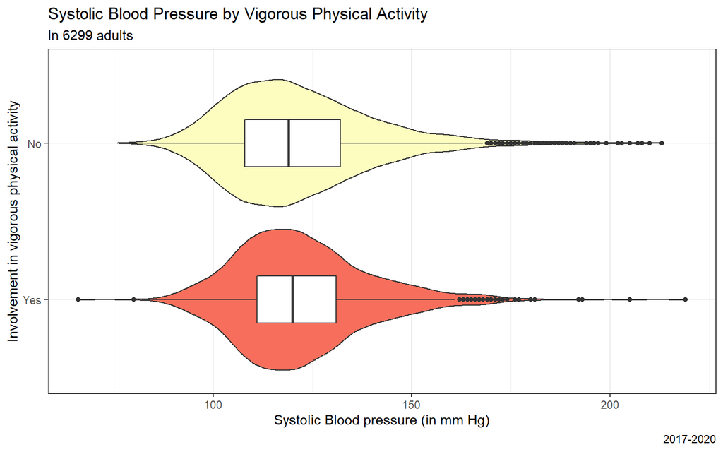

```r
p1 <- ggplot(data = analysis_b, aes(x = paq605_f, y = bpxosy1)) +
  geom_violin(aes(fill = paq605_f)) +
  geom_boxplot(width = 0.3) +
  scale_fill_viridis_d(begin = 0.7, option = "A") +
  guides(fill = "none", col = "none") +
  coord_flip()+
  labs(title = "Systolic Blood Pressure by Vigorous Physical Activity",
       subtitle= "In 6299 adults",
       caption = "2017-2020",
       x = "Involvement in vigorous physical activity", y = "Systolic Blood pressure (in mm Hg)")
p1
```

There are at least a couple of candidate outliers in each group on the high end, which suggest some potential for meaningful skew.

We could also build a pair of Normal Q-Q plots.

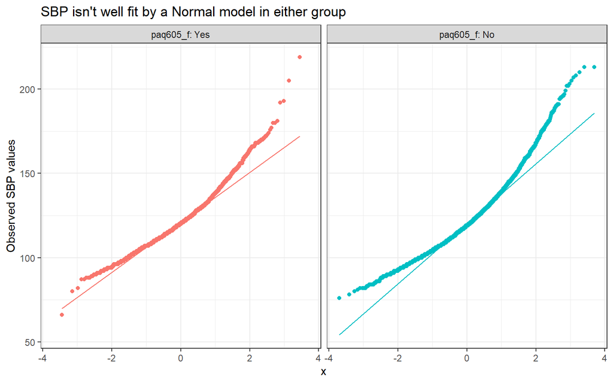

```r
ggplot(analysis_b, aes(sample = bpxosy1, col = paq605_f)) +
  geom_qq() + geom_qq_line() +
  facet_wrap(~ paq605_f, labeller = "label_both") +
  guides(col = FALSE) +
  guides(scale = "none" ) +
  theme_bw() +
  labs(y = "Observed SBP values",
       title = "SBP isn't well fit by a Normal model in either group")
```

The Normal q-q plot suggests right skew distribution in both the categories. There’s room for concern about whether a test that requires Normal distributions in the populations is a good choice here.

## 5.3 Main Analysis

As you’ll recall, we have three main methods for building confidence intervals in an independent samples analysis:

- Welch’s t test (t test without assuming equal variances)
- The Pooled t test (t test with equal variances assumed)
- The Bootstrap, using `bootdif`

### 5.3.1 The Bootstrap for comparing means from two independent samples

The other approach we have for independent samples comparisons that doesn’t require Normality is the bootstrap, and specifically, the `bootdif` function. This approach returns to estimating the difference in population means, but gives a different answer depending on the choice of random number seed. Here is a 90% confidence interval for the difference between the physically active and physically non-active population `bpxosy1` distributions based on the bootstrap.

```r
set.seed(4312022)
s_bootstrap <- bootdif(analysis_b$bpxosy1, analysis_b$paq605_f, conf.level = 0.90)
s_bootstrap
```

```
Mean Difference            0.05            0.95
     -0.5969535      -1.4076050       0.2116861
```

So, I think the bootstrap procedure would be most appropriate here, due to the non-Normality (and in particular the asymmetry) in the samples.

## 5.4 Conclusions

We find a range of possible values which crosses zero for the difference between the population mean sbp for those who are physically active and not active, based on our sample of respondents with complete data on sbp. This conclusion is motivated by a bootstrap estimate to compare the two groups with complete data on sbp. I feel this is the most justified approach based on the apparent skew in the data.

# 6 Analysis C: Comparing 3+ Population ranks via Kruskal Wallis

## 6.1 The Question

Is the distribution of systolic blood pressure same across the four categories of salt intake?

## 6.2 Describing the Data

I’ll start by looking at the range of the `bpxosy1` data within each `drqsprerp` (salt used in preparation) group.

```r
analysis_c <- study1 |> select(seqn, ridstatr, ridageyr, riagendr_f, bpxosy1, drqsprep_f, bpq020_f, smq681_f, whq030_f, paq605_f)

mosaic::favstats(bpxosy1 ~ drqsprep_f, data = analysis_c) |>
    kable(dig=2) |> kable_styling(font_size = 18)
```

| drqsprep_f | min | Q1 | median | Q3 | max | mean | sd | n | missing |
| --- | --- | --- | --- | --- | --- | --- | --- | --- | --- |
| Never | 82 | 112 | 124 | 137 | 213 | 126.40 | 20.89 | 526 | 0 |
| Rarely | 81 | 109 | 119 | 133 | 219 | 122.44 | 19.01 | 1067 | 0 |
| Occasionally | 66 | 109 | 119 | 131 | 203 | 121.70 | 17.89 | 1990 | 0 |
| Very Often | 76 | 109 | 119 | 130 | 213 | 120.94 | 17.34 | 2716 | 0 |

### 6.2.1 Graphical Summaries

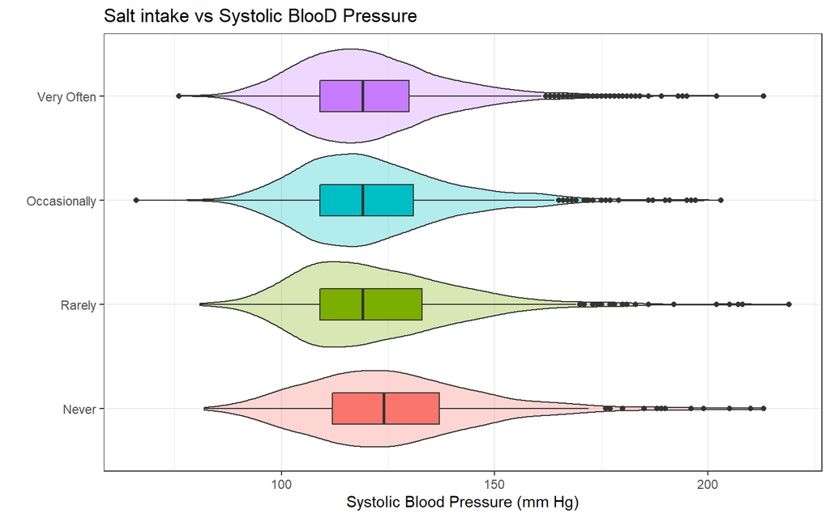

```r
ggplot(analysis_c, aes(x = drqsprep_f, y = bpxosy1, fill = drqsprep_f)) +
  geom_violin(alpha = 0.3) +
  geom_boxplot(width = 0.3) +
  coord_flip() +
  guides(fill = FALSE) +
  theme_bw() +
  labs(title = "Salt intake vs Systolic BlooD Pressure",
       y = "Systolic Blood Pressure (mm Hg)",
       x = "")
```

- The individual category data look as though they may be right skewed with potential outliers.
- I expect that a Kruskal-Wallis approach may also be useful here.

### 6.2.2 Numerical Summaries

```r
mosaic::favstats(bpxosy1 ~ drqsprep_f, data = analysis_c) |>
    kable(dig=2) |> kable_styling(font_size = 18)
```

| drqsprep_f | min | Q1 | median | Q3 | max | mean | sd | n | missing |
| --- | --- | --- | --- | --- | --- | --- | --- | --- | --- |
| Never | 82 | 112 | 124 | 137 | 213 | 126.40 | 20.89 | 526 | 0 |
| Rarely | 81 | 109 | 119 | 133 | 219 | 122.44 | 19.01 | 1067 | 0 |
| Occasionally | 66 | 109 | 119 | 131 | 203 | 121.70 | 17.89 | 1990 | 0 |
| Very Often | 76 | 109 | 119 | 130 | 213 | 120.94 | 17.34 | 2716 | 0 |

## 6.3 Main Analysis

We have at least two available methods for building statistical inferences when comparing more than two independent samples.

- Analysis of Variance
- The Kruskal-Wallis Test

I’ll build hypothesis tests, and compare the distributions of `BPXOSY1` across levels of `salt intake` using a 90% confidence level.

### 6.3.1 Kruskal-Wallis Test

```r
kruskal.test(bpxosy1 ~ drqsprep_f, data = analysis_c)
```

```
    Kruskal-Wallis rank sum test

data:  bpxosy1 by drqsprep_f
Kruskal-Wallis chi-squared = 31.976, df = 3, p-value = 5.294e-07
```

- This result suggests only that the separation we observe between the systolic blood pressure values for the four salt intake categories is consistent with some true differences between those groups.

## 6.4 Conclusions

The distribution of systolic blood pressure same across the four categories of salt intake is statistically different. Another approach to answer my research question could have been doing a transformation of my outcome and then running an anova and TukeyHSD.

# 7 Analysis D: Two-Way (2 x 2) Contingency Table

## 7.1 The Question

We’ll look at the association of `smoking` with `hypertension` in this analysis.

## 7.2 Describing the Data

Let’s look at the 2x2 table we get.

```r
analysis_d <- study1 |> select(seqn, ridstatr, ridageyr, riagendr_f, bpxosy1, drqsprep_f, bpq020_f, smq681_f, whq030_f, paq605_f)


table(analysis_d$smq681_f, analysis_d$bpq020_f)
```

```
             Hypertension No Hypertension
  Smoker              518            1031
  Non-smoker         1525            3225
```

## 7.3 Main Analysis

```r
t1 <- table(analysis_d$smq681_f, analysis_d$bpq020_f)

twoby2(t1 + 2, conf.level = 0.90)
```

```
2 by 2 table analysis:
------------------------------------------------------
Outcome   : Hypertension
Comparing : Smoker vs. Non-smoker

           Hypertension No Hypertension    P(Hypertension) 90% conf. interval
Smoker              520            1033             0.3348    0.3154   0.3548
Non-smoker         1527            3227             0.3212    0.3102   0.3324

                                   90% conf. interval
             Relative Risk: 1.0424    0.9736   1.1161
         Sample Odds Ratio: 1.0638    0.9605   1.1782
Conditional MLE Odds Ratio: 1.0638    0.9585   1.1802
    Probability difference: 0.0136   -0.0088   0.0364

             Exact P-value: 0.3181
        Asymptotic P-value: 0.3192
------------------------------------------------------
```

```r
  # uses Bayesian augmentation, 90% confidence level
```

- The relative risk of hypertension given the subject is a smoker vs hypertension in non-smokers, which is estimated to be 1.04, and based on its 90% confidence interval is clearly not detectably different from 1 at $\alpha = 0.10$.
- The odds ratio describing the odds of hypertension given smokers vs non smokers, which is estimated to be 1.06, and is clearly not detectably different from 1 at $\alpha = 0.10$.

## 7.4 Conclusions

Our primary conclusions about the study we’ve done here in Analysis D is motivated by the fact that the 90% confidence intervals for the RR and the OR cross 1, and that the probability difference isn’t detectably different from 0, either, with 90% confidence.

# 8 Analysis E: Two-Way (2 x 3) Contingency Table

## 8.1 The Question

I’ll look at the association of two categorical factors we created earlier: `weight_history` and `hypertension` in this analysis. We’re interested in whether there is an association between the subjects hypertension across the subjects in different weight categories.

My research Question - Is there a statistically detectable difference between hypertension across different weight categories?

## 8.2 Describing the Data

Let’s store this initial table of interest as `table_E1`

```r
analysis_e <- study1 |> select(seqn, ridstatr, ridageyr, riagendr_f, bpxosy1, drqsprep_f, bpq020_f, smq681_f, whq030_f, paq605_f)

table_E1 <- table(analysis_e$bpq020_f, analysis_e$whq030_f)

table_E1
```

```
                  Ideal_weight Underweight Overweight
  Hypertension            1345          78        620
  No Hypertension         2021         261       1974
```

We could add the marginal totals, I suppose.

```r
analysis_e |>
  tabyl(bpq020_f, whq030_f) |>
  adorn_totals(where = c("row", "col"))
```

```
        bpq020_f Ideal_weight Underweight Overweight Total
    Hypertension         1345          78        620  2043
 No Hypertension         2021         261       1974  4256
           Total         3366         339       2594  6299
```

## 8.3 Main Analysis

### 8.3.1 Running the Pearson $\chi^2$ Test

I’ll run the Pearson $\chi^2$ test using:

```r
chisq.test(table_E1)
```

```
    Pearson's Chi-squared test

data:  table_E1
X-squared = 186.89, df = 2, p-value < 2.2e-16
```

### 8.3.2 Checking Assumptions - The Cochran Conditions

The “Cochran conditions”, which require that we have:

- no cells with 0 counts
- at least 80% of the cells in our table with counts of 5 or higher
- expected counts in each cell of the table should be 5 or more

### 8.3.3 An Association Plot for the 2x3 Table

The `assocplot` function in R produces a plot that indicates deviations from the assumption of independence of rows and columns in a two-way table.

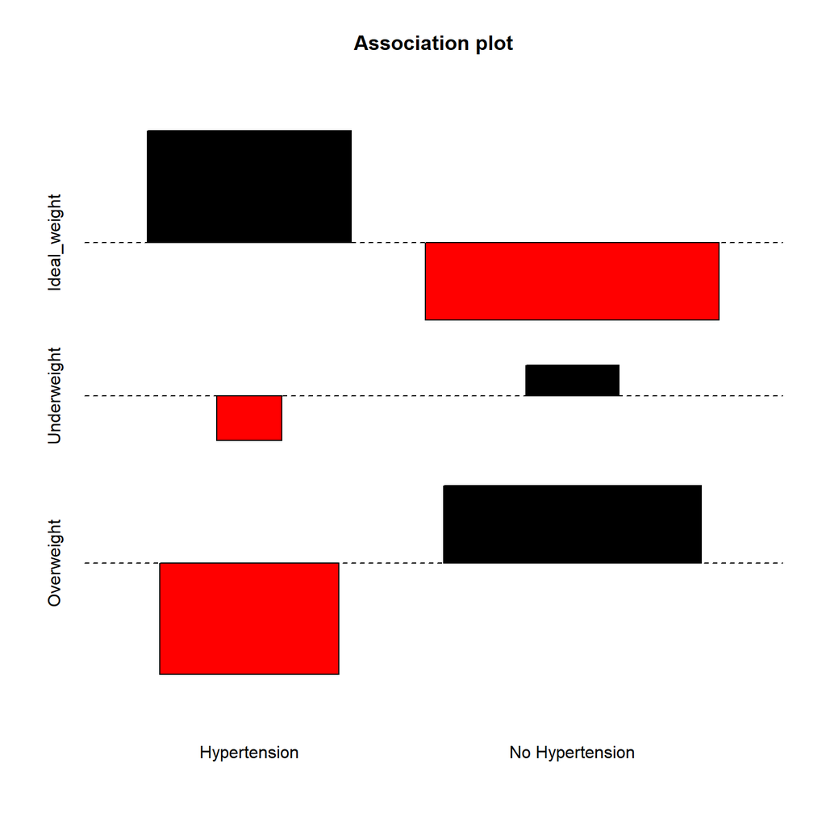

```r
assocplot(table_E1, main= "Association plot")
```

We can see that the independence model really doesn’t work well for the cells with larger shapes here, which we note especially in the overweight and ideal weight categories. .